**MECH437: Artificial Intelligence for M.E.**  
**Final Exam - Part 2**  
**Thursday, 06/08/2023, 09:00~11:00 PM**

By Prof. Seungchul Lee  
http://iai.postech.ac.kr/  
Industrial AI Lab at POSTECH

# Problem 1: Unsupervised to Supervised (K-means Clustering to KNN & DT)

If you remember the midterm exam, we had a situation where Sam has a dataset (denoted as Z below) that consists of two types of battery data: lithium battery data (denoted as X below) and aluminum battery data (denoted as Y below) where $Z = X + Y$. However, for this final exam, let's consider a situation where Sam does not know the labels of each dataset. That means Sam does not know whether the given data belongs to lithium batteries or aluminum batteries. In other words, Sam is just given the data Z without X and Y information. We will first use K-means to assign labels (class 0 & class 1) and employ supervised regression algorithms on each class.

```python
import numpy as np
import matplotlib.pyplot as plt

np.random.seed(42)

X = np.random.uniform(low=-1, high=1, size=(100, 2))
X[:, 1] = 5 * X[:, 0]**2 + np.random.normal(loc=0, scale=1, size=100) + 5

Y = np.random.uniform(low=-1, high=1, size=(100, 2))
Y[:, 1] = -8 * (Y[:, 0]-0.4)**2 + np.random.normal(loc=0, scale=1, size=100)

Z = np.concatenate([X, Y])

# X: lithium battery data, Y: aluminum battery data, Z: battery dataset
# X.shape = (100,2)
# Y.shape = (100,2)
# Z.shape = (200,2)
```

1) Initially, Sam thought that building a single regression model that can fit into the dataset (Z) would be appropriate, given that the dataset is all about batteries. Was Sam right about building a single regression model for the dataset? Use any regression algorithm that you have learned after the midterm exam. (Is the regression satisfactory?)

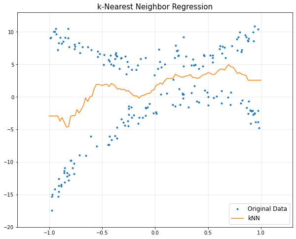

```python
## write your code here
```

2) Sam was not satisfied with the results above, so he decided to classify the dataset (Z) into two separate groups by using K-means Clustering! Group the dataset (Z) into two classes (class 0 : C0 & class 1 : C1) with K-means Clustering. (You must NOT use X and Y information - this problem assumes the unsupervised situation)

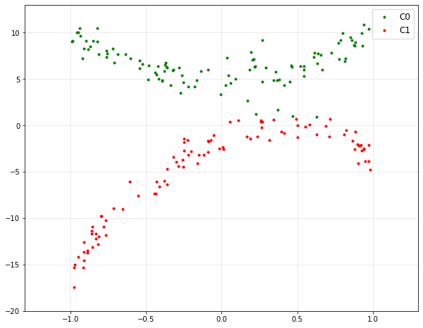

```python
## write your code here
```

3) Now, Sam recognizes that it is necessary to build two separate regression algorithms for two separate classes of batteries. Using any regression algorithm you learned after the midterm exam, find and plot an approximate curve for each class of data. (Build two regression models for C0 and C1 separately by infering labels assigned by K-means Clustering).

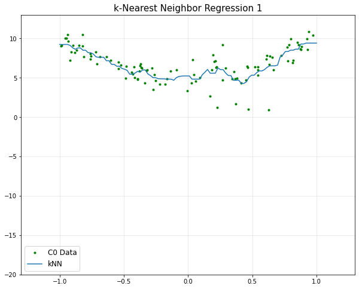

```python
## write your code here
```

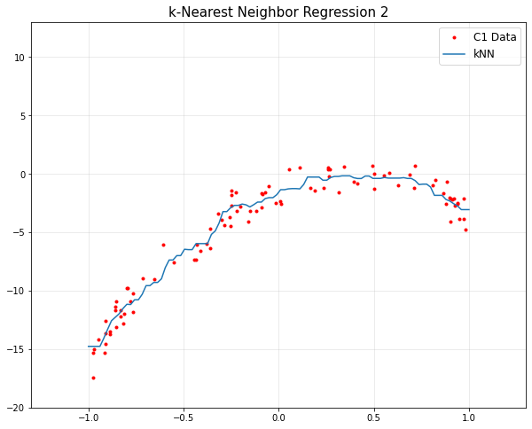

```python
## write your code here
```

# Problem 2: Dimensionality Reduction

1) Read the image and decompose the image using SVD (i.e., compute $U, \Sigma, V$).

Download [image](https://www.dropbox.com/s/js0t2o3n7htmkfi/postech_logo.jpg?dl=1)

```python
## write your code
```

2) Compress the image using 5, 10, 20, 100, and 150 singular values, respectively.

[figure not shown]

[figure not shown]

[figure not shown]

[figure not shown]

[figure not shown]

```python
## write your code
```

3) Determine how many sigular values are needed to compress the image and explain why. Do not worry about the color.

```python
## write the reason for your determination
```

# Problem 3: Dimensionality Reduction

We will now discuss an eigenface problem that is dealt with in the classroom.

- Download [eigenfaces](https://www.dropbox.com/s/ehbe3p8kces76ev/eigenfaces.npy?dl=1)

1) The shape of "faces" is (32256, 2410). Column of "faces" is images that have been flatten, and 2410 means the number of images. Each column represents each face of Yale university students. The shape of the original image is $168\times192$. Visualize one image, but the face should be $192\times168$, not $168\times 192$.

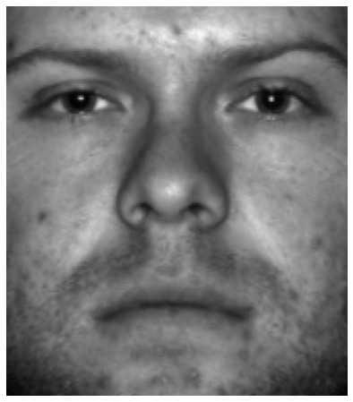

```python
import matplotlib.pyplot as plt
import numpy as np
%matplotlib inline

faces = np.load("eigenfaces.npy")
m = 168
n = 192

## write your code
```

2) We want to extract the eigenfaces. First, subtract the average of photos from the original images to build a mean-substracted training dataset. Second, decompose it via SVD. Third, visualize an average face and $U$ with the largest singular value.

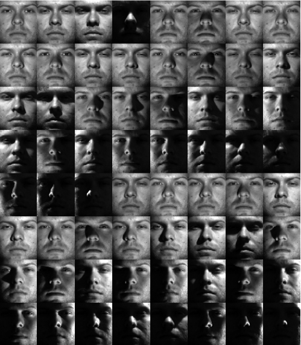

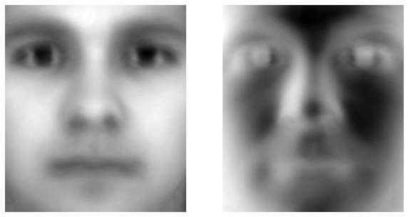

```python
## write your code
```

# Problem 4: ANN

Here, we will solve the same problem that we covered in class

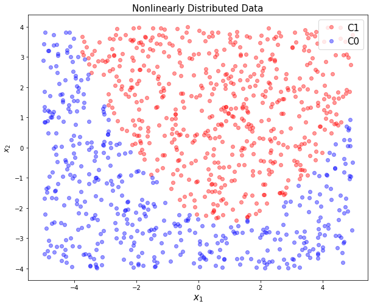

```python
from sklearn.preprocessing import OneHotEncoder
from sklearn.neural_network import MLPClassifier
import numpy as np
import matplotlib.pyplot as plt
m = 1000
x1 = 10*np.random.rand(m, 1) - 5
x2 = 8*np.random.rand(m, 1) - 4

g = - 0.5*(x1-1)**2 + 2*x2 + 5

C1 = np.where(g >= 0)[0]
C0 = np.where(g < 0)[0]
N = C1.shape[0]
M = C0.shape[0]
m = N + M

X1 = np.hstack([x1[C1], x2[C1]])
X0 = np.hstack([x1[C0], x2[C0]])

train_X = np.vstack([X1, X0])
train_X = np.asmatrix(train_X)

train_y = np.vstack([np.ones([N,1]), np.zeros([M,1])])
ohe = OneHotEncoder(handle_unknown='ignore')
train_y = ohe.fit_transform(train_y).toarray()

plt.figure(figsize=(10, 8))
plt.plot(x1[C1], x2[C1], 'ro', alpha = 0.4, label = 'C1')
plt.plot(x1[C0], x2[C0], 'bo', alpha = 0.4, label = 'C0')
plt.title('Nonlinearly Distributed Data', fontsize = 15)
plt.legend(loc = 1, fontsize = 15)
plt.xlabel(r'$x_1$', fontsize = 15)
plt.ylabel(r'$x_2$', fontsize = 12)
plt.show()
```

1) Classify the above given data using `MLPClassifier` in 2D plane with the hidden layer of size of 3 as shown below.

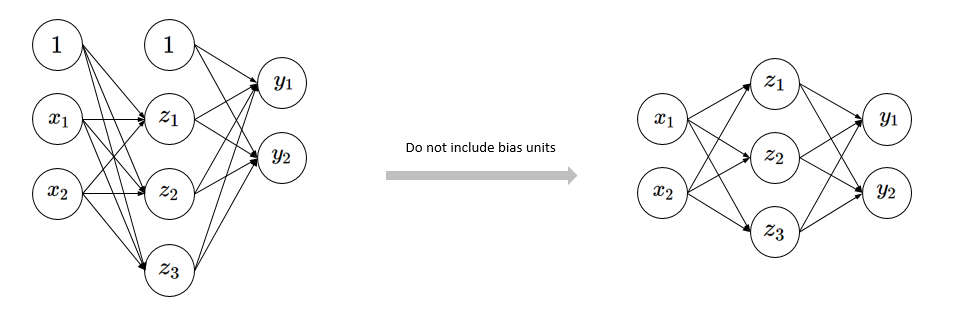

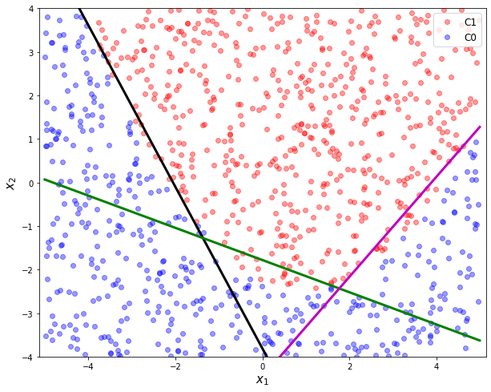

```python
## write your code here
```

2) Plot those data in Z-plane (hidden layer)

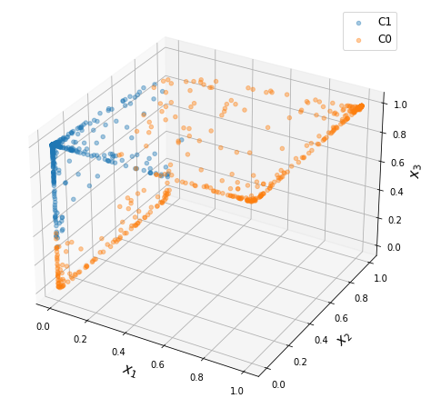

```python
## write your code here
```

3) Plot 2D hyperplane that separates those data into C1 and C0

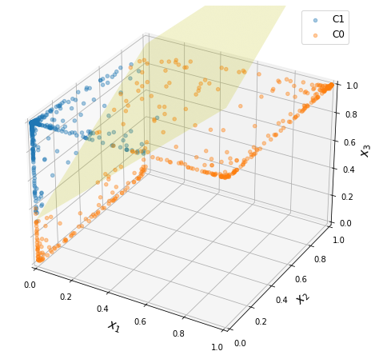

```python
## write your code here
```

# Problem 5 : Autoencoder

**PCA (Principal Component Analysis)**

- PCA is one of the oldest and most widely used dimensionality reduction algorithms. Its idea is to reduce the dimensionality of a dataset, while preserving as much 'variability' as possible. (but you don't need to fully understand the PCA algorithm for this problem.)

Actually, autoencoder is very similar to the PCA algorithm in terms of 'dimension reduction'. So, in this problem, we are going to build up PCA with autoencoder. While PCA is a linear dimension reduction method, the autoencoder has non-linear activation functions. Therefore, autoencoder without non-linear activation functions can be considered as PCA.

Now, we have 3D data. Run the below cell to load and 3D plot them.

**Data Download Link**

- [Download data](https://www.dropbox.com/s/cjc6kewusii4ssl/pca_autoencoder.npy?dl=1)

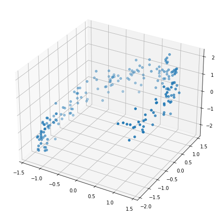

```python
import numpy as np
import matplotlib.pyplot as plt
from mpl_toolkits.mplot3d import Axes3D
%matplotlib inline

data = np.load('pca_autoencoder.npy')

fig = plt.figure(figsize = (10, 8))
ax = fig.add_subplot(111, projection = '3d')
ax.scatter(data[:,0], data[:,1], data[:,2])
plt.show()

X_train, X_test = data[:100], data[100:]
```

PCA result in 2D is shown as follows.

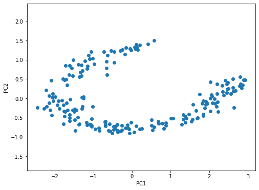

```python
# PCA on the data
from sklearn.decomposition import PCA

pca = PCA(n_components = 2)
pca.fit(data)
result = pca.transform(data)

plt.figure(figsize = (8, 6))
plt.plot(result[:,0], result[:,1], 'o')
plt.axis('equal')
plt.xlabel('PC1')
plt.ylabel('PC2')
plt.show()
```

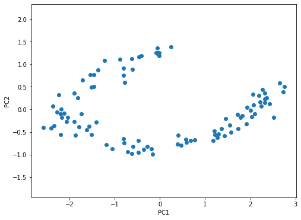

```python
#PCA exclusively on the test data
pca.fit(X_test)
result = pca.transform(X_test)

plt.figure(figsize = (8, 6))
plt.plot(result[:,0], result[:,1], 'o')
plt.axis('equal')
plt.xlabel('PC1')
plt.ylabel('PC2')
plt.show()
```

(1) Design your linear autoencoder model using ANN. (freely design your own network structure)  
Hint: you must use (activation = 'identity')

```python
## write your code here
```

2) After training your model, plot the test data on latent space. (You will be able to obtain similar result as PCA!!)

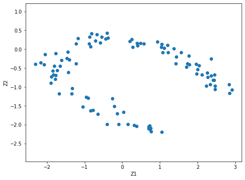

```python
## write your code here
```